# PA1_template

### Packages used:

```r
library(knitr)
library(dplyr)
```

```r
library(ggplot2)
```

### Read data

```r
data <- read.table(unz("activity.zip","activity.csv"), sep=",",header=T)
```

### What is mean total number of steps taken per day?

1. Make a histogram of the total number of steps taken each day

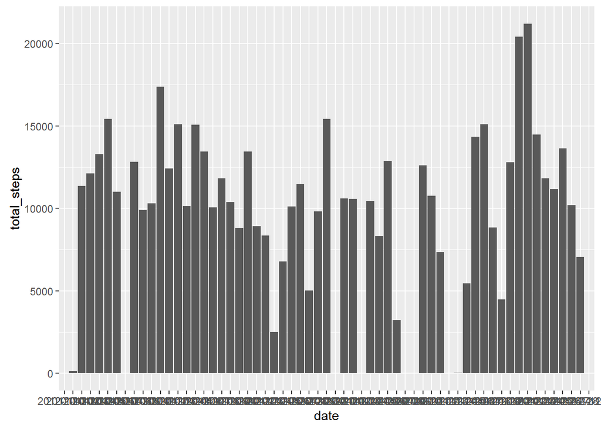

```r
s <- data %>% group_by(date) %>% summarize(total_steps=sum(steps, na.rm=T))

ggplot(data=s, aes(x=date, y=total_steps)) + geom_bar(stat="identity")
```

2. Calculate and report the mean and median total number of steps taken per day

```r
m <-data %>%
    group_by(date) %>%
    summarize(mean_steps=mean(steps, na.rm=T),
              median_steps=median(steps, na.rm=T))

print(m)
```

```
## Source: local data frame [61 x 3]
##
##          date mean_steps median_steps
##        (fctr)      (dbl)        (dbl)
## 1  2012-10-01         NA           NA
## 2  2012-10-02    0.43750            0
## 3  2012-10-03   39.41667            0
## 4  2012-10-04   42.06944            0
## 5  2012-10-05   46.15972            0
## 6  2012-10-06   53.54167            0
## 7  2012-10-07   38.24653            0
## 8  2012-10-08        NaN           NA
## 9  2012-10-09   44.48264            0
## 10 2012-10-10   34.37500            0
## ..        ...        ...          ...
```

### What is the average daily activity pattern?

1. Make a time series plot (i.e. type = “l”) of the 5-minute interval (x-axis) and the average number of steps taken, averaged across all days (y-axis)

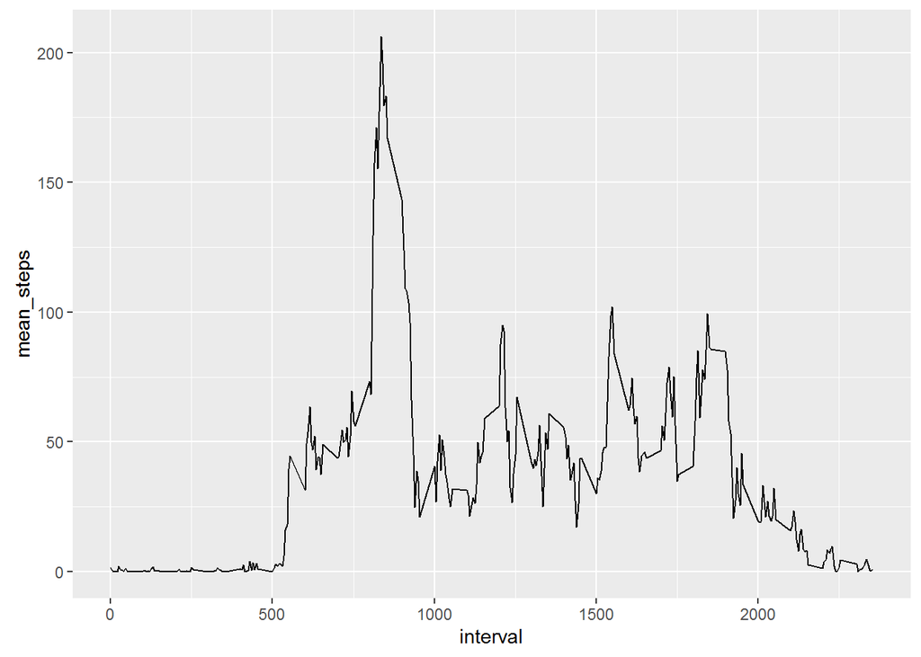

```r
a <- data %>%
     group_by(interval) %>%
     summarize(mean_steps = mean(steps, na.rm=T))

ggplot(data=a, aes(x=interval, y=mean_steps)) + geom_line()
```

2. Which 5-minute interval, on average across all the days in the dataset, contains the maximum number of steps?

```r
filter(a, mean_steps==max(a$mean_steps))
```

```
## Source: local data frame [1 x 2]
##
##   interval mean_steps
##      (int)      (dbl)
## 1      835   206.1698
```

### Imputing missing values

1. Calculate and report the total number of missing values in the dataset (i.e. the total number of rows with NAs)

```r
sum(is.na(data$steps))
```

```
## [1] 2304
```

2. Devise a strategy for filling in all of the missing values in the dataset. The strategy does not need to be sophisticated. For example, you could use the mean/median for that day, or the mean for that 5-minute interval, etc.

Fill in with mean for correponding interval

3. Create a new dataset that is equal to the original dataset but with the missing data filled in.

```r
data_new <- left_join(data, a, by=c("interval"="interval"))
data_new$steps <- ifelse(is.na(data_new$steps), data_new$mean_steps, data_new$steps)
data_new <- subset(data_new, select=-c(mean_steps))
```

The imputation replaces the NA and NaN mean and median with valid values. Overall, magnitude of mean and median remain unchanged.

```r
m_new <- data_new %>%
         group_by(date) %>%
         summarize(mean_steps = mean(steps),
                   median_steps = median(steps))
print(m_new)
```

```
## Source: local data frame [61 x 3]
##
##          date mean_steps median_steps
##        (fctr)      (dbl)        (dbl)
## 1  2012-10-01   37.38260     34.11321
## 2  2012-10-02    0.43750      0.00000
## 3  2012-10-03   39.41667      0.00000
## 4  2012-10-04   42.06944      0.00000
## 5  2012-10-05   46.15972      0.00000
## 6  2012-10-06   53.54167      0.00000
## 7  2012-10-07   38.24653      0.00000
## 8  2012-10-08   37.38260     34.11321
## 9  2012-10-09   44.48264      0.00000
## 10 2012-10-10   34.37500      0.00000
## ..        ...        ...          ...
```

### Are there differences in activity patterns between weekdays and weekends?

1. Create a new factor variable in the dataset with two levels – “weekday” and “weekend” indicating whether a given date is a weekday or weekend day.

```r
data$date2 <- as.Date(data$date)
data$weekday <- as.factor(ifelse(weekdays(data$date2) %in% c("Saturday","Sunday"),
                       "weekend","weekday"))
```

2. Make a panel plot containing a time series plot (i.e. type = “l”) of the 5-minute interval (x-axis) and the average number of steps taken, averaged across all weekday days or weekend days (y-axis).

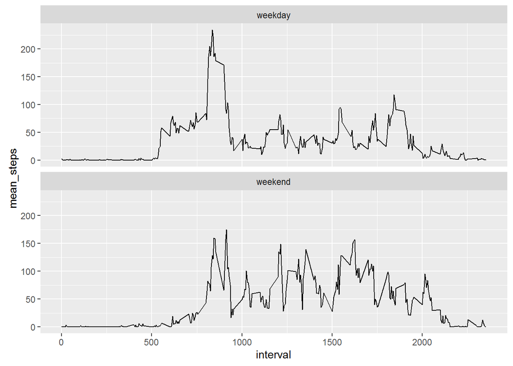

```r
p <- data %>%
     group_by(interval, weekday) %>%
     summarize(mean_steps = mean(steps, na.rm=T))

ggplot(data=p, aes(x=interval, y=mean_steps)) + geom_line() + facet_wrap(~weekday, ncol=1)
```